# Homework 4 - Machine Learning and Parallel Computing

## Due Date

March 29, 2026 by 11:59pm.

## Learning Objectives

- Apply feature engineering to prepare a real-world dataset for modelling.
- Tune hyperparameters correctly using cross-validation on the training set.
- Compare ML models on a regression task.
- Parallelize embarrassingly parallel workloads using `joblib`.

## Deliverables

Please answer all questions and interpret your findings. Upload both the `.qmd` and rendered `.html` to Quercus.

## Part 1: Machine Learning with the Ames Housing Dataset

The [Ames Housing Dataset](https://www.kaggle.com/c/house-prices-advanced-regression-techniques/data) contains 81 features describing residential properties sold in Ames, Iowa between 2006 and 2010. Our goal is to predict `SalePrice`. Please use fetch_openml to get the data from OpenML rather than Kaggle, https://www.openml.org/search?type=data&status=active&id=43926 (use fetch_openml(name=“house_prices”, version=1, as_frame=True, parser=“auto”))

```python
import subprocess
subprocess.run(["pip", "install", "xgboost", "scikit-learn"])

import pandas as pd
import numpy as np
from sklearn.datasets import fetch_openml
import xgboost as xgb
from plotnine import *
import matplotlib.pyplot as plt
import openml
from sklearn.model_selection import train_test_split, cross_val_score
from sklearn.metrics import mean_squared_error, r2_score
import time
from joblib import Parallel, delayed
```

```python
# df  = fetch_openml(data_id=43926, as_frame=True, parser="auto")
df = fetch_openml(name="house_prices", version=1, as_frame=True, parser="auto")
feature = df.data
target = df.target


print("Feature Shape:", feature.shape)
print("Target Shape:", target.shape)


data = feature.copy()
data["SalePrice"] = target
data = data.drop(columns=["Id"])
print("Data shape:", data.shape)

raw = data.copy()
```

```
Feature Shape: (1460, 80)
Target Shape: (1460,)
Data shape: (1460, 80)
```

### Question 1: Data Preparation and Feature Engineering (14 points)

**1a.** (3 points) Explore the target variable and the features.

- Plot the distribution of `SalePrice` and `log(SalePrice)` side by side. Report the skewness of each and indicate whether logging might be preferred for modeling.
- Print a summary table of the categorical columns showing: column name, number of unique values, and first few values. Use this to identify which columns are truly nominal (no order, e.g. `Neighborhood`) vs ordinal quality ratings (e.g. `ExterQual` with values `Ex/Gd/TA/Fa/Po`). Write a brief interpretation.

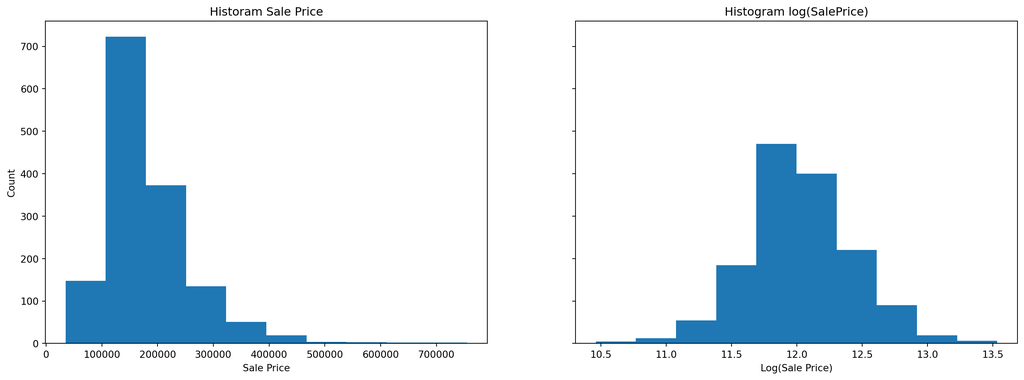

```python
fig, axes = plt.subplots(1, 2, figsize=(18, 6), sharey=True)

axes[0].hist(data["SalePrice"])
axes[0].set_xlabel("Sale Price")
axes[0].set_ylabel("Count")
axes[0].set_title("Historam Sale Price")

axes[1].hist(np.log(data["SalePrice"]))
axes[1].set_xlabel("Log(Sale Price)")
axes[1].set_title("Histogram log(SalePrice)")

plt.show()
```

```python
cat_cols = data.select_dtypes(include=["object", "category", "string"]).columns

summary = pd.DataFrame({
  "Column Name": cat_cols,
  "N Unique": data[cat_cols].nunique(),
  "First 5 Values": [data[col].unique()[:5] for col in cat_cols]
}
)

display(summary)
```

|  | Column Name | N Unique | First 5 Values |
| --- | --- | --- | --- |
| MSZoning | MSZoning | 5 | [RL, RM, 'C (all)', FV, RH] |
| Street | Street | 2 | [Pave, Grvl] |
| Alley | Alley | 2 | [nan, Grvl, Pave] |
| LotShape | LotShape | 4 | [Reg, IR1, IR2, IR3] |
| LandContour | LandContour | 4 | [Lvl, Bnk, Low, HLS] |
| Utilities | Utilities | 2 | [AllPub, NoSeWa] |
| LotConfig | LotConfig | 5 | [Inside, FR2, Corner, CulDSac, FR3] |
| LandSlope | LandSlope | 3 | [Gtl, Mod, Sev] |
| Neighborhood | Neighborhood | 25 | [CollgCr, Veenker, Crawfor, NoRidge, Mitchel] |
| Condition1 | Condition1 | 9 | [Norm, Feedr, PosN, Artery, RRAe] |
| Condition2 | Condition2 | 8 | [Norm, Artery, RRNn, Feedr, PosN] |
| BldgType | BldgType | 5 | [1Fam, 2fmCon, Duplex, TwnhsE, Twnhs] |
| HouseStyle | HouseStyle | 8 | [2Story, 1Story, 1.5Fin, 1.5Unf, SFoyer] |
| RoofStyle | RoofStyle | 6 | [Gable, Hip, Gambrel, Mansard, Flat] |
| RoofMatl | RoofMatl | 8 | [CompShg, WdShngl, Metal, WdShake, Membran] |
| Exterior1st | Exterior1st | 15 | [VinylSd, MetalSd, 'Wd Sdng', HdBoard, BrkFace] |
| Exterior2nd | Exterior2nd | 16 | [VinylSd, MetalSd, 'Wd Shng', HdBoard, Plywood] |
| MasVnrType | MasVnrType | 4 | [BrkFace, None, Stone, BrkCmn, nan] |
| ExterQual | ExterQual | 4 | [Gd, TA, Ex, Fa] |
| ExterCond | ExterCond | 5 | [TA, Gd, Fa, Po, Ex] |
| Foundation | Foundation | 6 | [PConc, CBlock, BrkTil, Wood, Slab] |
| BsmtQual | BsmtQual | 4 | [Gd, TA, Ex, nan, Fa] |
| BsmtCond | BsmtCond | 4 | [TA, Gd, nan, Fa, Po] |
| BsmtExposure | BsmtExposure | 4 | [No, Gd, Mn, Av, nan] |
| BsmtFinType1 | BsmtFinType1 | 6 | [GLQ, ALQ, Unf, Rec, BLQ] |
| BsmtFinType2 | BsmtFinType2 | 6 | [Unf, BLQ, nan, ALQ, Rec] |
| Heating | Heating | 6 | [GasA, GasW, Grav, Wall, OthW] |
| HeatingQC | HeatingQC | 5 | [Ex, Gd, TA, Fa, Po] |
| CentralAir | CentralAir | 2 | [Y, N] |
| Electrical | Electrical | 5 | [SBrkr, FuseF, FuseA, FuseP, Mix] |
| KitchenQual | KitchenQual | 4 | [Gd, TA, Ex, Fa] |
| Functional | Functional | 7 | [Typ, Min1, Maj1, Min2, Mod] |
| FireplaceQu | FireplaceQu | 5 | [nan, TA, Gd, Fa, Ex] |
| GarageType | GarageType | 6 | [Attchd, Detchd, BuiltIn, CarPort, nan] |
| GarageFinish | GarageFinish | 3 | [RFn, Unf, Fin, nan] |
| GarageQual | GarageQual | 5 | [TA, Fa, Gd, nan, Ex] |
| GarageCond | GarageCond | 5 | [TA, Fa, nan, Gd, Po] |
| PavedDrive | PavedDrive | 3 | [Y, N, P] |
| PoolQC | PoolQC | 3 | [nan, Ex, Fa, Gd] |
| Fence | Fence | 4 | [nan, MnPrv, GdWo, GdPrv, MnWw] |
| MiscFeature | MiscFeature | 4 | [nan, Shed, Gar2, Othr, TenC] |
| SaleType | SaleType | 9 | [WD, New, COD, ConLD, ConLI] |
| SaleCondition | SaleCondition | 6 | [Normal, Abnorml, Partial, AdjLand, Alloca] |

Summary:

- We can see that Sale Price is quite right-skewed while log(SalePrice) is more normal shaped. With more even-distributed data, we may expect clearer boundary and more spread error. Therefore, we prefer log-transformed
- While we can’t really ensure which one is nominal and ordinal, we can have a good heuristics based on number of unique. First good heuristics for ordinal is if the column contain (Quality, Condition, or QC). Second heuristics for ordinal is the unique value contains [TA, Fa, Gd, Po, Ex] (This value has order)

**1b.** (8 points) Handle missing values, engineer features, encode ordinal columns, set the target, and binary encode the remaining nominal categoricals. Complete all steps:

- Fill **numeric** missing values with `0`; fill **categorical** missing values with `'None'`.
- Create the derived features below, then drop the listed component columns:

| New feature | Formula | Columns to drop |
| --- | --- | --- |
| `TotalSF` | `TotalBsmtSF + 1stFlrSF + 2ndFlrSF` | `TotalBsmtSF`, `1stFlrSF`, `2ndFlrSF` |
| `HouseAge` | `YrSold − YearBuilt` | `YearBuilt` |
| `RemodAge` | `YrSold − YearRemodAdd` | `YearRemodAdd` |

Note: keep `YrSold` (captures market conditions). `PoolArea` and `GarageArea` already encode existence and size — no binary flag needed.

- **Ordinal encode** the quality/condition columns by mapping their string levels to integers. Many features use the scale `Ex > Gd > TA > Fa > Po`, and encoding them as numbers (5–1) preserves the ordering that dummy variable encoding would discard. Use the mappings below:

```python
qual_map = {'None': 0, 'Po': 1, 'Fa': 2, 'TA': 3, 'Gd': 4, 'Ex': 5}
qual_cols = ['ExterQual', 'ExterCond', 'BsmtQual', 'BsmtCond',
             'HeatingQC', 'KitchenQual', 'FireplaceQu',
             'GarageQual', 'GarageCond', 'PoolQC']

other_ordinal = {
    'BsmtExposure': {'None': 0, 'No': 1, 'Mn': 2, 'Av': 3, 'Gd': 4},
    'BsmtFinType1': {'None': 0, 'Unf': 1, 'LwQ': 2, 'Rec': 3, 'BLQ': 4, 'ALQ': 5, 'GLQ': 6},
    'BsmtFinType2': {'None': 0, 'Unf': 1, 'LwQ': 2, 'Rec': 3, 'BLQ': 4, 'ALQ': 5, 'GLQ': 6},
    'GarageFinish': {'None': 0, 'Unf': 1, 'RFn': 2, 'Fin': 3},
    'Fence':        {'None': 0, 'MnWw': 1, 'GdWo': 2, 'MnPrv': 3, 'GdPrv': 4},
    'Functional':   {'Sal': 1, 'Sev': 2, 'Maj2': 3, 'Maj1': 4,
                     'Mod': 5, 'Min2': 6, 'Min1': 7, 'Typ': 8},
    'LotShape':     {'IR3': 1, 'IR2': 2, 'IR1': 3, 'Reg': 4},
    'LandSlope':    {'Sev': 1, 'Mod': 2, 'Gtl': 3},
    'PavedDrive':   {'N': 0, 'P': 1, 'Y': 2},
}
```

- Use log `SalePrice` as your target and drop `SalePrice`. Create dummy variables of the remaining `object`-dtype columns (the nominal categoricals) using `pd.get_dummies(...)`. Print the final feature count and summarize the feature engineered variables (but no need to summarize all of the dummy variables).

```python
# Since we use drop and this cell is the first augmenting cells, we replace with raw
data = raw.copy()

# Fill Missing Values
numeric_cols = data.select_dtypes(include=["number"]).columns
data[numeric_cols] = data[numeric_cols].fillna(0)

cat_cols = data.columns.difference(numeric_cols)
data[cat_cols] = data[cat_cols].fillna("None")

# Feature Engineering
data["TotalSF"] = data["TotalBsmtSF"] + data["1stFlrSF"] + data["2ndFlrSF"]
data["HouseAge"] = data["YrSold"] - data["YearBuilt"]
data["RemodAge"] = data["YrSold"] - data["YearRemodAdd"]

data.drop(columns=["TotalBsmtSF", "1stFlrSF", "2ndFlrSF", "YearBuilt", "YearRemodAdd"], inplace=True)

# Get the Numeric Cols Before Encode Ordinal and Nominal Columns
numeric_cols = data.select_dtypes(include=["number"]).columns

# Ordinal Encode
data[qual_cols] = data[qual_cols].replace(qual_map)

other_ordinal_cols = [key for key in other_ordinal.keys()]
for col in other_ordinal_cols:
  data[col] = data[col].replace(other_ordinal[col])



# Get Dummies and log_transformed
ordinal_cols = qual_cols + [key for key in other_ordinal.keys()]
nominal_cols = cat_cols.difference(ordinal_cols)

data = pd.get_dummies(
    data,
    columns=nominal_cols,
    drop_first=True,
    dtype=int
)

data["SalePrice"] = np.log(data["SalePrice"])


# Print Total Feature number and Head of dataset, classified by columns type.
print("Total Final Feature", len(data.columns) - 1) # - 1 for target variable
print("Summary Numeric Columns:", data[numeric_cols].shape[1], "Columns")
display(data[numeric_cols].head(3))

print("\n\n")

print("Summary Ordinal Columns:", data[ordinal_cols].shape[1], "Columns")
display(data[ordinal_cols].head(3))

print("\n\n")

nominal_cols = data.columns.difference(numeric_cols.tolist() + ordinal_cols + ["SalePrice"], sort=False)
print("Summary Nominal Columns:", data[nominal_cols].shape[1], "Columns")
display(data[nominal_cols].head(3))
```

```
Total Final Feature 201
Summary Numeric Columns: 35 Columns
```

|  | MSSubClass | LotFrontage | LotArea | OverallQual | OverallCond | MasVnrArea | BsmtFinSF1 | BsmtFinSF2 | BsmtUnfSF | LowQualFinSF | ... | 3SsnPorch | ScreenPorch | PoolArea | MiscVal | MoSold | YrSold | SalePrice | TotalSF | HouseAge | RemodAge |
| --- | --- | --- | --- | --- | --- | --- | --- | --- | --- | --- | --- | --- | --- | --- | --- | --- | --- | --- | --- | --- | --- |
| 0 | 60 | 65.0 | 8450 | 7 | 5 | 196.0 | 706 | 0 | 150 | 0 | ... | 0 | 0 | 0 | 0 | 2 | 2008 | 12.247694 | 2566 | 5 | 5 |
| 1 | 20 | 80.0 | 9600 | 6 | 8 | 0.0 | 978 | 0 | 284 | 0 | ... | 0 | 0 | 0 | 0 | 5 | 2007 | 12.109011 | 2524 | 31 | 31 |
| 2 | 60 | 68.0 | 11250 | 7 | 5 | 162.0 | 486 | 0 | 434 | 0 | ... | 0 | 0 | 0 | 0 | 9 | 2008 | 12.317167 | 2706 | 7 | 6 |

3 rows × 35 columns

```
Summary Ordinal Columns: 19 Columns
```

|  | ExterQual | ExterCond | BsmtQual | BsmtCond | HeatingQC | KitchenQual | FireplaceQu | GarageQual | GarageCond | PoolQC | BsmtExposure | BsmtFinType1 | BsmtFinType2 | GarageFinish | Fence | Functional | LotShape | LandSlope | PavedDrive |
| --- | --- | --- | --- | --- | --- | --- | --- | --- | --- | --- | --- | --- | --- | --- | --- | --- | --- | --- | --- |
| 0 | 4 | 3 | 4 | 3 | 5 | 4 | 0 | 3 | 3 | 0 | 1 | 6 | 1 | 2 | 0 | 8 | 4 | 3 | 2 |
| 1 | 3 | 3 | 4 | 3 | 5 | 3 | 3 | 3 | 3 | 0 | 4 | 5 | 1 | 2 | 0 | 8 | 4 | 3 | 2 |
| 2 | 4 | 3 | 4 | 3 | 5 | 4 | 3 | 3 | 3 | 0 | 2 | 6 | 1 | 2 | 0 | 8 | 3 | 3 | 2 |

```
Summary Nominal Columns: 148 Columns
```

|  | Alley_None | Alley_Pave | BldgType_2fmCon | BldgType_Duplex | BldgType_Twnhs | BldgType_TwnhsE | CentralAir_Y | Condition1_Feedr | Condition1_Norm | Condition1_PosA | ... | SaleType_CWD | SaleType_Con | SaleType_ConLD | SaleType_ConLI | SaleType_ConLw | SaleType_New | SaleType_Oth | SaleType_WD | Street_Pave | Utilities_NoSeWa |
| --- | --- | --- | --- | --- | --- | --- | --- | --- | --- | --- | --- | --- | --- | --- | --- | --- | --- | --- | --- | --- | --- |
| 0 | 1 | 0 | 0 | 0 | 0 | 0 | 1 | 0 | 1 | 0 | ... | 0 | 0 | 0 | 0 | 0 | 0 | 0 | 1 | 1 | 0 |
| 1 | 1 | 0 | 0 | 0 | 0 | 0 | 1 | 1 | 0 | 0 | ... | 0 | 0 | 0 | 0 | 0 | 0 | 0 | 1 | 1 | 0 |
| 2 | 1 | 0 | 0 | 0 | 0 | 0 | 1 | 0 | 1 | 0 | ... | 0 | 0 | 0 | 0 | 0 | 0 | 0 | 1 | 1 | 0 |

3 rows × 148 columns

Summary:

**1c.** (3 points) Split into 70% train and 30% test (set `random_state=370`). Print the shapes of `X_train`, `X_test`, `y_train`, `y_test`. Report the mean and standard deviation of `y_train` and `y_test`.

```python
feature_cols = data.columns.difference(["SalePrice"])
target_col = "SalePrice"

X = data[feature_cols].apply(pd.to_numeric)
y = data[target_col]

X_train, X_test, y_train, y_test = train_test_split(X, y, test_size = 0.3, random_state=370)

print("y_train:", "Mean:", np.round(y_train.mean(), 5), "Std:", y_train.std())
print("y_test: ", "Mean:", np.round(y_test.mean(), 5), "Std:", y_test.std())
```

```
y_train: Mean: 12.02963 Std: 0.40038938608636093
y_test:  Mean: 12.01102 Std: 0.3974065663949653
```

### Question 2: Baseline — Ridge Regression (10 points)

**2** (10 points) Write a brief description of what ridge regression is, and then fit `RidgeCV` model using `alphas=np.logspace(-3, 3, 50)` and `cv=5`. Explain what you are tuning and report the chosen `alpha_`. Then estimate the 5-fold CV RMSE using the chosen alpha. The on the test set report R$^2$ and RMSE (log scale) and convert log-scale predictions back to dollars to report test R$^2$ and RMSE in dollars. Interpret the model performance metrics.

Ridge Regression: A linear regression method but with L2 Regularization on weight/coefficient. So, we add penalty term on the loss function, which
$$\lambda \sum_{j=1}^p \beta_j^2$$

```python
from sklearn.linear_model import RidgeCV

alphas = np.logspace(-3, 3, 50)

best_ridge = RidgeCV(alphas=alphas, cv=5)
best_ridge.fit(X_train, y_train)

best_scores_ridge = best_ridge.best_score_

print("Best alpha:", best_ridge.alpha_)

y_pred = best_ridge.predict(X_test)
y_pred_exp = np.exp(y_pred)
y_test_exp = np.exp(y_test)


r2_ridge_log = r2_score(y_test, y_pred)
rmse_ridge_log = np.sqrt(mean_squared_error(y_test, y_pred))
r2_ridge_dollar = r2_score(y_test_exp, y_pred_exp)
rmse_ridge_dollar = np.sqrt(mean_squared_error(y_test_exp, y_pred_exp))


print("Log Scale")
print("R^2:", r2_ridge_log)
print("RMSE:", rmse_ridge_log)

print("\n")
print("Real Scale")
print("R^2:", r2_ridge_dollar)
print("RMSE:", rmse_ridge_dollar, "Dollars")
```

```
Best alpha: 25.595479226995334
Log Scale
R^2: 0.8317315639620715
RMSE: 0.16283210269521464


Real Scale
R^2: -0.23045796388959983
RMSE: 87675.66220571619 Dollars
```

Summary:

- Log-Scale: Our model, with its feature, can explain 83.2% of variability in log(SalePrice). The RMSE of this model is 0.163 “log-Dollars”
- Normal Scale: With its feature trained on log-scale, this model predict worst than just predicting with mean SalePrice (Since the value of R^2 is negative). The RMSE is 87675 dollars
- We can see that our model become so much worst when we try to convert back from log-scale into normal scale. One of the reason is because our model train on completely different objective. For example, notice that in training, the difference (10 with 11) is “same” as (11 with 12). However, in dollar scale, the error on (e^12 - e^11) is much bigger than (e^11 - e^10).

### Question 3: Random Forest (12 points)

**3a.** (10 points) Tune a `RandomForestRegressor` by trying two different values for `n_estimators`, three different `max_features`, two different `max_depth` values, and two different `min_samples_leaf` values (24 combinations). Write a function `fit_rf_cv(n_est, max_feat, max_d, min_leaf)` that fits the model and returns the CV RMSE, then run the grid search both serially and in parallel with `Parallel(n_jobs=4)`. Keep `random_state=370` and `n_jobs=1` inside the model. Report serial time and speedup time. Report the best combination in a table. Then fit the best Random Forest on the full training set, report test R$^2$ and RMSE (log scale and dollars). Interpret and discuss.

```python
from sklearn.ensemble import RandomForestRegressor

n_estimators = [100, 200]
max_features = [1/3, 1/2, 3/4]
max_depth = [10, 20]
min_sample_leaf = [3, 9]


param_grid = [
    {'n_est': n, 'max_feat': max_feat, 'max_d': max_d, 'min_leaf': msl}
    for max_d in max_depth
    for max_feat in max_features
    for n in n_estimators
    for msl in min_sample_leaf
]

def fit_rf_cv(n_est, max_feat, max_d, min_leaf):
    rf = RandomForestRegressor(
            n_estimators=n_est,
            max_features=max_feat,
            max_depth=max_d,
            min_samples_leaf=min_leaf,
            random_state=370,
            oob_score=True,
            n_jobs=1
    )

    scores = cross_val_score(
        rf,
        X_train,
        y_train,
        cv=5,
        scoring="neg_root_mean_squared_error"
    )

    return -scores.mean()
```

```python
# SERIAL TIME
t0 = time.time()
scores = []
for param in param_grid:
    scores.append(fit_rf_cv(**param))

serial_time = time.time() - t0
print("Time Needed (Serial):", serial_time)


# PARALLEL TIME
t0 = time.time()
Parallel(n_jobs=4, prefer="threads")(delayed(fit_rf_cv)(**p) for p in param_grid)
parallel_time = time.time() - t0
print("Time Needed (Parallel):", parallel_time)
print(f"SPEED UP: {serial_time/parallel_time:.1f}x")
```

```
Time Needed (Serial): 83.93858981132507
Time Needed (Parallel): 32.321577310562134
SPEED UP: 2.6x
```

```python
# Best Model

best_index = np.argmin(scores)
best_param_serial = param_grid[best_index]
param_df = pd.DataFrame([best_param_serial])

best_scores_rf = scores[best_index]
print("Best Score RMSE:", best_scores_rf)
print("Best Parameter:")
display(param_df.head())

best_rf = RandomForestRegressor(
            n_estimators=best_param_serial["n_est"],
            max_features=best_param_serial["max_feat"],
            max_depth=best_param_serial["max_d"],
            min_samples_leaf=best_param_serial["min_leaf"],
            random_state=370,
            oob_score=True,
            n_jobs=1
        )
best_rf.fit(X_train, y_train)


y_pred = best_rf.predict(X_test)
y_pred_exp = np.exp(y_pred)
y_test_exp = np.exp(y_test)


r2_rf_log = r2_score(y_test, y_pred)
rmse_rf_log = np.sqrt(mean_squared_error(y_test, y_pred))
r2_rf_dollar = r2_score(y_test_exp, y_pred_exp)
rmse_rf_dollar = np.sqrt(mean_squared_error(y_test_exp, y_pred_exp))


print("Log Scale")
print("R^2:", r2_rf_log)
print("RMSE:", rmse_rf_log)

print("\n")
print("Real Scale")
print("R^2:", r2_rf_dollar)
print("RMSE:", rmse_rf_dollar, "Dollars")
```

```
Best Score RMSE: 0.14188137261175968
Best Parameter:
```

|  | n_est | max_feat | max_d | min_leaf |
| --- | --- | --- | --- | --- |
| 0 | 100 | 0.333333 | 20 | 3 |

```
Log Scale
R^2: 0.8801204608595052
RMSE: 0.13743939486038412


Real Scale
R^2: 0.8542492923122108
RMSE: 30175.258558940557 Dollars
```

Summary:

**3b.** (2 points) Plot the top 15 features. Do the most important features make intuitive sense for predicting house prices?

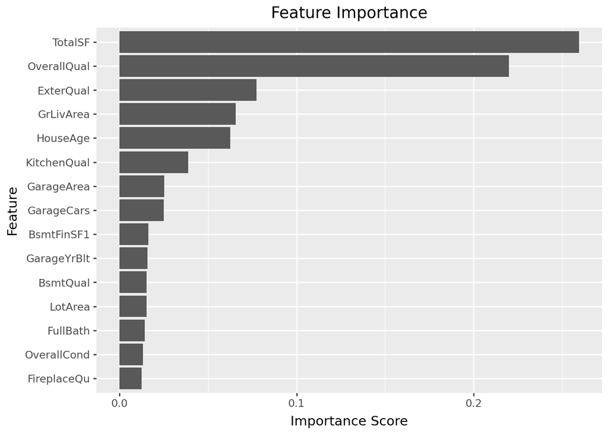

```python
rf_importances_r = best_rf.feature_importances_
reg_feature_cols = X_train.columns.tolist()

imp_df_r = pd.DataFrame({
    'feature': reg_feature_cols,
    'importance': rf_importances_r
}).sort_values('importance', ascending=False)
imp_df_r['feature'] = pd.Categorical(imp_df_r['feature'], categories=imp_df_r['feature'][::-1])

imp_df_r = imp_df_r.iloc[:15, :]

(
    ggplot(imp_df_r, aes(x="feature", y="importance")) +
    geom_col() +
    coord_flip() +
    labs(x="Feature", y="Importance Score", title="Feature Importance")
)
```

Summary:

- The first 2 most important features is Total Square Floor and Overall Quality. Notice that these column has importance 2x of other columns importance. These columns are make sense since TotalSF represents how big is the house and Overall Quality represents the quality of the house. By intuition, we can have a pretty good approximation given how big is the house and the quality of it. Further, HouseAge is also one of the most important feature
- Notice that 8th-15th columns have similar importance, suggesting either equal columns’ importance or highly correlated columns (Many columns contain the same information)

### Question 4: XGBoost with Parallel Hyperparameter Search (12 points)

**4a.** (8 points) Define a hyperparameter grid with **at least 3 values** for each of `max_depth`, `learning_rate`, `n_estimators`, and `subsample` (minimum 81 combinations). Print the total number of combinations. Write a function `fit_xgb_cv(params)` that builds an `XGBRegressor` with the given `params` (plus `n_jobs=1`, `random_state=370`, `verbosity=0`), runs 5-fold CV with `scoring='neg_root_mean_squared_error'` and `n_jobs=1` on `(X_train, y_train)`, and returns `(params, mean_cv_rmse)`. Run the grid search both serially and in parallel with `Parallel(n_jobs=4)`. Report serial time and parallel speedup. Find the best hyperparameter combination (lowest mean CV RMSE), refit on the full training set, and report test R$^2$ and RMSE in log scale and dollars. Interpret and discuss.

```python
import xgboost as xgb

param_grid_xgb = [
    {'max_depth': d, 'learning_rate': lr, 'n_estimators': n, 'subsample': ss}
    for d in [5, 10, 15]
    for lr in [0.001, 0.01, 0.1]
    for n in [50, 100, 150]
    for ss in [0.3, 0.5, 0.7]
]


def fit_xgb_cv(params):
    """Evaluate one hyperparameter combination via 5-fold CV."""
    # YOUR CODE HERE
    # 1. Build an XGBClassifier with the given params, n_jobs=1,
    #    eval_metric='logloss', random_state=42, verbosity=0
    # 2. Run cross_val_score with cv=5, scoring='roc_auc', n_jobs=1 on (X_train, y_train)
    # 3. Return (params, scores.mean())

    model = xgb.XGBRegressor(
        **params,
        random_state=370,
        verbosity=0
    )

    scores = cross_val_score(
            model, X_train, y_train,
            cv=5, scoring="neg_root_mean_squared_error",
            n_jobs=1
        )

    mean_cv_rmse = -scores.mean()
    return (params, mean_cv_rmse)
```

```python
# SERIAL TIME
t0 = time.time()
serial_results = [fit_xgb_cv(p) for p in param_grid_xgb]
time_serial = time.time() - t0
print(f"Serial grid search: {time_serial:.2f}s  ({len(param_grid_xgb)} combinations)")


# PARALLEL TIME
t0 = time.time()
parallel_results = Parallel(n_jobs=4, prefer='threads')(delayed(fit_xgb_cv)(p) for p in param_grid_xgb)
time_parallel = time.time() - t0

print(f"Parallel grid search (4 workers): {time_parallel:.2f}s")
print(f"Speedup: {time_serial / time_parallel:.2f}x")
```

```
Serial grid search: 212.82s  (81 combinations)
Parallel grid search (4 workers): 104.17s
Speedup: 2.04x
```

```python
# Best Model

results_xgb = serial_results + parallel_results
scores_xgb = [result_xgb[1] for result_xgb in results_xgb]

best_scores_xgb = np.min(scores_xgb)
best_index_xgb = np.argmin(scores_xgb) % len(serial_results)

best_param_xgb = results_xgb[best_index_xgb][0]
best_xgb = xgb.XGBRegressor(
        **best_param_xgb,
        random_rate=370,
        verbosity=0
)

best_xgb.fit(X_train, y_train)

y_pred = best_xgb.predict(X_test)
y_pred_exp = np.exp(y_pred)
y_test_exp = np.exp(y_test)


r2_xgb_log = r2_score(y_test, y_pred)
rmse_xgb_log = np.sqrt(mean_squared_error(y_test, y_pred))
r2_xgb_dollar = r2_score(y_test_exp, y_pred_exp)
rmse_xgb_dollar = np.sqrt(mean_squared_error(y_test_exp, y_pred_exp))


print("Log Scale")
print("R^2:", r2_xgb_log)
print("RMSE:", rmse_xgb_log)

print("\n")
print("Real Scale")
print("R^2:", r2_xgb_dollar)
print("RMSE:", rmse_xgb_dollar, "Dollars")
```

```
Log Scale
R^2: 0.8959362849817263
RMSE: 0.1280525893985471


Real Scale
R^2: 0.881903629633859
RMSE: 27162.137226613584 Dollars
```

**4b.** (2 points) Now try **inner-level parallelism**: write `fit_xgb_cv_inner(params)` that uses `n_jobs=4` on the `XGBRegressor` itself (so each model uses 4 threads internally) and `n_jobs=1` in `cross_val_score`, then run the grid search serially. Report wall-clock time and compare it to the serial (`n_jobs=1`) and outer-parallel (`Parallel(n_jobs=4)`) approaches from 4a. Which strategy is fastest and why?

```python
def fit_xgb_cv_inner(params):
    model = xgb.XGBRegressor(
        **params,
        n_jobs=4,
        random_state=370,
        verbosity=0
    )

    scores = cross_val_score(
            model, X_train, y_train,
            cv=5, scoring="neg_root_mean_squared_error",
            n_jobs=1
        )

    mean_cv_rmse = -scores.mean()
    return (params, mean_cv_rmse)

# PARALLEL INNER TIME
t0 = time.time()
parallel_inner_results = [fit_xgb_cv_inner(p) for p in param_grid_xgb]
time_parallel_inner = time.time() - t0
print(f"Parallel Inner grid search: {time_parallel_inner:.2f}s  ({len(param_grid_xgb)} combinations)")
print(f"Parallel Outer grid serach: {time_parallel:.2f}s  ({len(param_grid_xgb)} combinations)")
```

```
Parallel Inner grid search: 127.58s  (81 combinations)
Parallel Outer grid serach: 104.17s  (81 combinations)
```

**4c.** (2 points) Plot the top 15 features. How do they compare to the random forest variable importance?

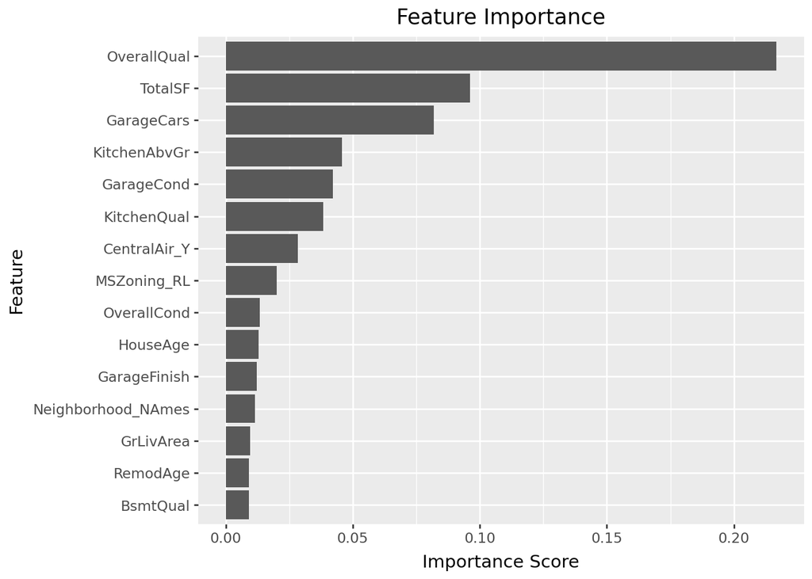

```python
# Features' Importance

xgb_importances_r = best_xgb.feature_importances_
reg_feature_cols = X_train.columns.tolist()

imp_df_xgb = pd.DataFrame({
    'feature': reg_feature_cols,
    'importance': xgb_importances_r
}).sort_values('importance', ascending=False)
imp_df_xgb['feature'] = pd.Categorical(imp_df_xgb['feature'], categories=imp_df_xgb['feature'][::-1])

imp_df_xgb = imp_df_xgb.iloc[:15, :]

(
    ggplot(imp_df_xgb, aes(x="feature", y="importance")) +
    geom_col() +
    coord_flip() +
    labs(x="Feature", y="Importance Score", title="Feature Importance")
)
```

Summary:

- We can see that the top 2 features are same between XGB and RF, despite reverse order and significantly bigger gap between the first and second feature. Not only that, the second and the third feature in XGB has significantly smaller gap in term of importance. Therefore, it suggests that “Overall Quality” is really an important/strong predictor.
- There is also new predictor, which is an indicator whether the kitchen above groud or not.
- The same pattern on 8th-15th predictors appears again, where all of them has similar importance. It can mean that these columns either “equally-important” or “Highly correlated columns (redundant information)”

### Question 5: Model Comparison (6 points)

**5a.** (6 points) Assemble a summary table with columns: `Model`, `Best CV RMSE (log)`, `Test RMSE (log)`, `Test RMSE ($)`, `Test R2`. Include Ridge, Random Forest, and XGBoost. On a single figure with three side-by-side panels, plot predicted vs actual `SalePrice` (in dollars) for Ridge, Random Forest, and XGBoost. Add a 1-to-1 reference line to each panel. Interpret and discuss your findings.

```python
Model = ["Ridge Regression", "Random Forest", "XGBoost"]
Best_CV_RMSE = [best_scores_ridge, best_scores_rf, best_scores_xgb]
Test_RMSE_log = [rmse_ridge_log, rmse_rf_log, rmse_xgb_log]
Test_RMSE_dollar = [rmse_ridge_dollar, rmse_rf_dollar, rmse_xgb_dollar]
Test_R2 = [r2_ridge_dollar, r2_rf_dollar, r2_xgb_dollar]

comparison_df = pd.DataFrame()
comparison_df["Model"] = Model
comparison_df["Best CV RMSE (log)"] = Best_CV_RMSE
comparison_df["Test RMSE (log)"] = Test_RMSE_log
comparison_df["Test RMSE ($)"] = Test_RMSE_dollar
comparison_df["Test R2"] = Test_R2

display(comparison_df)
```

[output not shown]

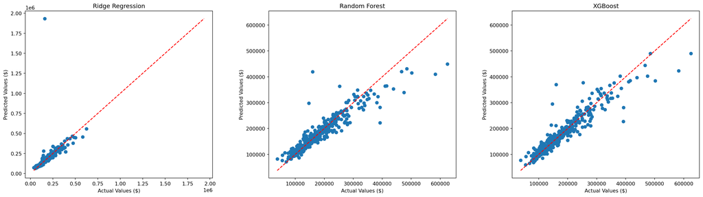

```python
fig, axes = plt.subplots(1, 3, figsize=(24, 6))

best_models = [best_ridge, best_rf, best_xgb]
title = ["Ridge Regression", "Random Forest", "XGBoost"]

for i, model in enumerate(best_models):
    y_pred = model.predict(X_test)

    y_pred_exp = np.exp(y_pred)
    y_test_exp = np.exp(y_test)

    axes[i].scatter(y=y_pred_exp, x=y_test_exp)

    mn = min(min(y_test_exp), min(y_pred_exp))
    mx = max(max(y_test_exp), max(y_pred_exp))
    axes[i].plot([mn, mx], [mn, mx], '--', color="red")

    axes[i].set_title(title[i])
    axes[i].set_ylabel("Predicted Values ($)")
    axes[i].set_xlabel("Actual Values ($)")

fig.subplots_adjust(wspace=0.3, hspace=0.5)
plt.show()
```

Summary:

- From the table, we can see see that Ridge Regression has significantly worse performance that other models. Based on the graph, we can see that there is a point where the error is unexpectedly very high, which may inflates overall RMSE. However, we doesn’t know whether the bad performance of Ridge Regression is caused solely by this outliers or just “averagely” higher error compared to other models.
- The performance of Random Forest and XGBoost is similar with XGBoost performs better slightly. While these model Test RMSE in log-scale is similar with the one from Ridge Regression, Random Forest and XGBoost still preserve their performance in real (dollar) scale.
- Since the performance seems similar, then the model selection boiled down into whether we want interpretability/explainibility or pure predictive performance. In term of explainibility to general audience, random forest is much easier to explain since it’s just a collection of tree (Decision algorithm). However, if we want pure predictive power, XGBoost is way to go model since it performs better in this dataset and generally perform better in general tabular dataset

## Part 2: Parallel Functions

### Question 6: Monte Carlo pi Estimation (12 points)

**6a.** (4 points) Write `estimate_pi(N, seed=None)` that:

1. Draws `N` uniform random points in [0,1] × [0,1]
2. Counts how many satisfy x² + y² ≤ 1 (inside the unit circle)
3. Returns 4 × (count inside) / N

Run it with N = 1,000, 100,000, and 1,000,000. For each, report the estimate, the absolute error from `np.pi`, and the serial time. How does accuracy scale with N? How does run time scale?

```python
def estimate_pi(N, seed=None):
    rng = np.random.default_rng(seed)
    x = rng.uniform(0, 1, size=N)
    y = rng.uniform(0, 1, size=N)

    # counter = 0
    # for i in range(N):
    #     counter += (x[i]**2 + y[i]**2 <= 1)

    counter = np.sum(x**2 + y**2 <= 1)

    return 4 * counter/N

Ns = [1000, 100000, 1000000]
results = []
times = []
errors = []

for n in Ns:
    t0 = time.time()
    result = estimate_pi(n)

    results.append(result)
    times.append(time.time() - t0)
    errors.append(np.abs(np.pi - result))


results_df = pd.DataFrame()
results_df["N"] = Ns
results_df["Estimates"] = results
results_df["Error"] = errors
results_df["Serial Time"] = times

display(results_df)
```

|  | N | Estimates | Error | Serial Time |
| --- | --- | --- | --- | --- |
| 0 | 1000 | 3.076000 | 0.065593 | 0.000151 |
| 1 | 100000 | 3.149360 | 0.007767 | 0.001421 |
| 2 | 1000000 | 3.140784 | 0.000809 | 0.016244 |

**6b.** (4 points) Run `estimate_pi(N=100_000)` serially with seeds 0–1999 (2,000 runs). Record the serial time. Report the mean and standard deviation of the estimates.

```python
t0 = time.time()
results_serial = []
for i in range(2000):
    results_serial.append(estimate_pi(N=100000, seed=i))

serial_time = time.time() - t0
print("Serial Time:", serial_time, "s")
print("\n")
print("Results:")
print("Mean:", np.mean(results))
print("Std:", np.std(results))
```

[output not shown]

**6c.** (4 points) Repeat 6b in parallel with `Parallel(n_jobs=4, prefer="threads")`. Report speedup. Verify the mean estimate is within 0.001 of the serial result. Why is `prefer="threads"` a good choice here? Is the speedup closer to 4x compared to the XGBoost grid search? Why?

```python
t0 = time.time()
results_parallel = Parallel(n_jobs=4, prefer="threads")(delayed(estimate_pi)(N=100000, seed=i) for i in range(2000))

parallel_time = time.time() - t0
print("Parallel Time:", parallel_time, "s")
print(f"Speedup: {serial_time/parallel_time}x")
print("\n")
closeness = np.allclose(results_serial, results_parallel, atol=0.001, rtol=0)

if closeness:
    print("Close Enough (each element differs less than 0.001)")

else:
    print("Some elements deviates higher than 0.001")
    results_serial = np.array(results_serial)
    results_parallel = np.array(results_parallel)
    print("Max Difference:", np.max(np.abs(results_serial - results_parallel)))
```

```
Parallel Time: 0.7305536270141602 s
Speedup: 3.474096360377578x


Close Enough (each element differs less than 0.001)
```

### Question 7: Bootstrap Confidence Interval for Test RMSE (12 points)

Bootstrapping gives a confidence interval for any model metric without making distributional assumptions. Each resample is independent, making it naturally parallel.

**7a.** (4 points) Using the best XGBoost model fitted in Question 4, write a function `boot_rmse(idx)` that:

1. Selects rows `idx` from `X_test` and `y_test` (resample with replacement)
2. Predicts with the best XGBoost model
3. Returns the RMSE on the resample (log scale)

```python
def boot_rmse(idx):
    X_b = X_test.iloc[idx]
    y_b = y_test.iloc[idx]

    y_pred_b = best_xgb.predict(X_b)
    return np.sqrt(mean_squared_error(y_b, y_pred_b))
```

**7b.** (4 points) Generate 1,000 bootstrap index arrays using a fixed random seed, run `boot_rmse` serially, and compute the 95% percentile bootstrap CI for test RMSE. Time the computation.

```python
B = 1000
rng = np.random.default_rng(123)
n_test = len(y_test)

boot_indices = [rng.integers(0, n_test, size=n_test) for _ in range(B)]

t0 = time.perf_counter()
rmse_boot_serial = np.array([boot_rmse(idx) for idx in boot_indices])
t1 = time.perf_counter()

ci_serial = np.percentile(rmse_boot_serial, [2.5, 97.5])
serial_time = t1 - t0

print("Serial 95% bootstrap CI:", ci_serial)
print(f"Serial time: {serial_time}s")
```

```
Serial 95% bootstrap CI: [0.10940558 0.15001133]
Serial time: 43.1168658999959s
```

**7c.** (4 points) Run the same 1,000 bootstrap resamples in parallel with `Parallel(n_jobs=4, prefer="threads")`. Compare the CI to 7b and report speedup. Why is `prefer="threads"` important here, what happens if you use the default process backend instead? Do the serial and parallel CIs agree? Should they, given that both use the same pre-generated index arrays?

```python
t0 = time.perf_counter()
rmse_boot_parallel = Parallel(n_jobs=4, prefer='threads')(delayed(boot_rmse)(idx) for idx in boot_indices)
t1 = time.perf_counter()

rmse_boot_parallel = np.array(rmse_boot_parallel)
ci_parallel = np.percentile(rmse_boot_parallel, [2.5, 97.5])
parallel_time = t1 - t0

print("Parallel 95% bootstrap CI:", ci_parallel)
print("Parallel time:", parallel_time)
print("Speedup:", serial_time / parallel_time)
print("Same bootstrap RMSEs:", np.allclose(rmse_boot_serial, rmse_boot_parallel))
```

```
Parallel 95% bootstrap CI: [0.10940558 0.15001133]
Parallel time: 38.899201399995945
Speedup: 1.1084254778557072
Same bootstrap RMSEs: True
```

Summary: